# Caso de estudio 1

Camilo Alejandro Raba

Juan Andrés Camacho

2024-12-17

1. Para Bogotá en 2023-2 ($t=9$), calcule la media posterior, el coeficiente de variación posterior y el intervalo de credibilidad al 95% de confianza para la media $\theta$, la desviación estándar $\sigma$ y el coeficiente de variación $\zeta=100\,\frac{\sigma}{|\theta|}\%$. Reporte los resultados tabularmente.

Inferencia sobre el puntaje promedio de Matemáticas de Bogotá para 2023-2

| Estimación | CV | L. Inf | L. Sup |
| --- | --- | --- | --- |
| 55.082 | 0.008 | 54.239 | 55.925 |

Inferencia sobre la desviación estandar del puntaje promedio de Matemáticas de Bogotá para 2023-2

| Estimación | CV | L. Inf | L. Sup |
| --- | --- | --- | --- |
| 11.994 | 0.025 | 11.424 | 12.607 |

Inferencia sobre el coeficiente de variación del puntaje promedio de Matemáticas de Bogotá para 2023-2

| Estimación | CV | L. Inf | L. Sup |
| --- | --- | --- | --- |
| 21.776 | 0.026 | 20.673 | 22.963 |

2. En 2023-2 ($t=9$), elabore el ranking de los cinco departamentos con mejores calificaciones promedio. Para cada uno de estos departamentos calcule la media posterior, el coeficiente de variación posterior y el intervalo de credibilidad al 95% de confianza para la media $\theta$. Reporte los resultados tabularmente. Además, genere una visualización de estos cinco departamentos mediante un mapa de Colombia que utilice una escala de colores adecuada para representar la media posterior de la media $\theta$.

Top 5 departamentos con mejores puntajes promedio de matemáticas

|  | Estimación | CV | L. Inf | L. Sup |
| --- | --- | --- | --- | --- |
| Santander | 55.403 | 0.014 | 53.885 | 56.942 |
| Bogotá, D.C. | 55.082 | 0.008 | 54.239 | 55.925 |
| Huila | 54.678 | 0.021 | 52.404 | 56.978 |
| Boyacá | 54.025 | 0.017 | 52.201 | 55.815 |
| Cundinamarca | 53.848 | 0.010 | 52.751 | 54.955 |

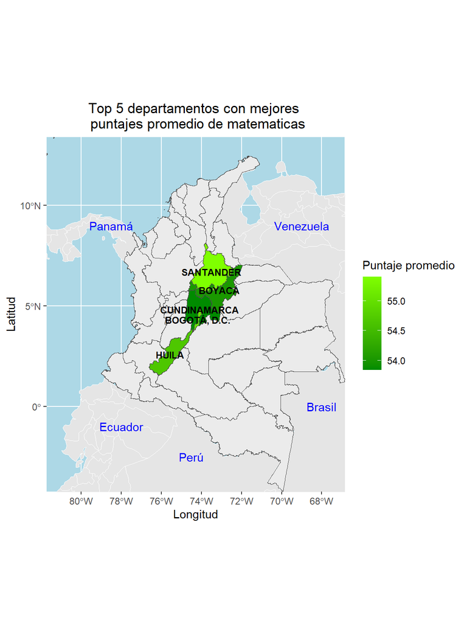

3. En 2023-2 ($t=9$), elabore el ranking de los cinco departamentos con peores calificaciones promedio. Para cada uno de estos departamentos calcule la media posterior, el coeficiente de variación posterior y el intervalo de credibilidad al 95% de confianza para la media $\theta$. Reporte los resultados tabularmente. Además, genere una visualización de estos cinco departamentos mediante un mapa de Colombia que utilice una escala de colores adecuada para representar la media posterior de la media $\theta$.

Top 5 departamentos con peores puntajes promedio de matemáticas

|  | Estimación | CV | L. Inf | L. Sup |
| --- | --- | --- | --- | --- |
| Vichada | 38.024 | 0.147 | 27.099 | 49.058 |
| Chocó | 38.376 | 0.037 | 35.642 | 41.153 |
| Amazonas | 45.319 | 0.108 | 35.540 | 55.078 |
| San Andrés | 45.454 | 0.103 | 36.192 | 54.751 |
| La Guajira | 45.851 | 0.025 | 43.589 | 48.101 |

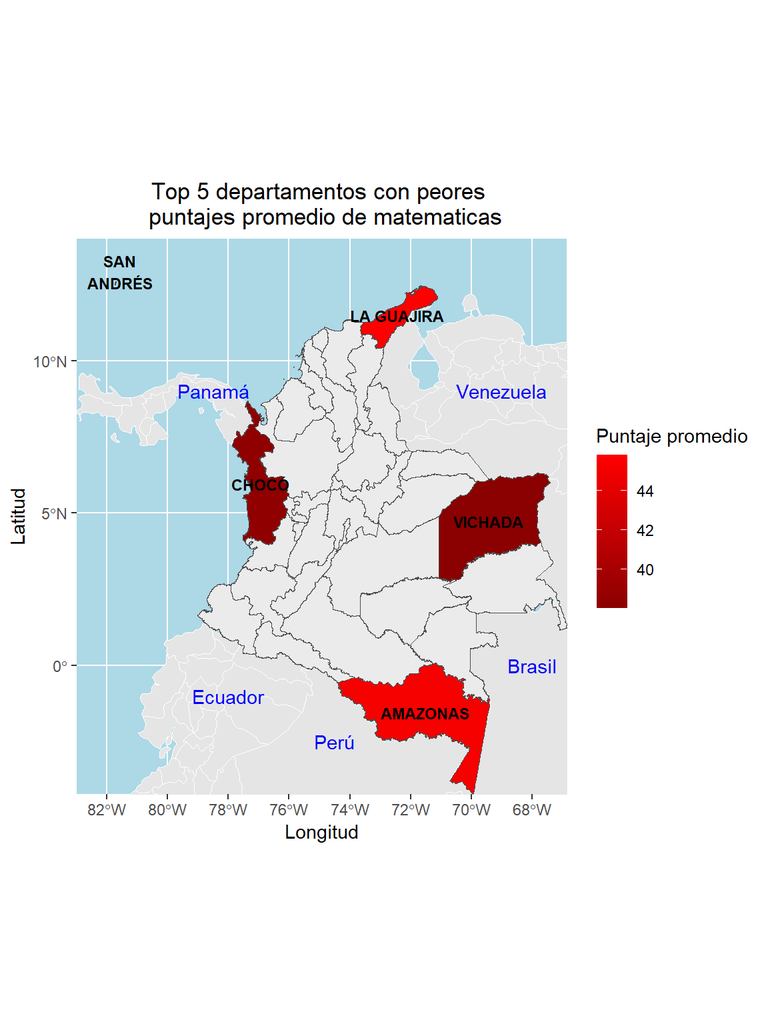

4. Para Bogotá en todos los periodos ($t=1,\ldots,9$), calcule la media posterior y el intervalo de credibilidad al 95% de confianza para la media $\theta$. Presente los resultados mediante una visualización que muestre simultáneamente las medias posteriores y los intervalos de credibilidad.

Inferencia sobre el puntaje promedio de Bogotá a través del tiempo

|  | Estimación | CV | L. Inf | L. Sup |
| --- | --- | --- | --- | --- |
| 2015-2 | 54.162 | 0.007 | 53.369 | 54.961 |
| 2016-2 | 55.625 | 0.007 | 54.891 | 56.352 |
| 2017-2 | 54.096 | 0.007 | 53.350 | 54.831 |
| 2018-2 | 55.405 | 0.009 | 54.440 | 56.386 |
| 2019-2 | 54.819 | 0.009 | 53.850 | 55.803 |
| 2020-2 | 55.614 | 0.010 | 54.513 | 56.734 |
| 2021-2 | 54.345 | 0.008 | 53.544 | 55.152 |
| 2022-2 | 54.650 | 0.008 | 53.828 | 55.485 |
| 2023-2 | 55.082 | 0.008 | 54.239 | 55.925 |

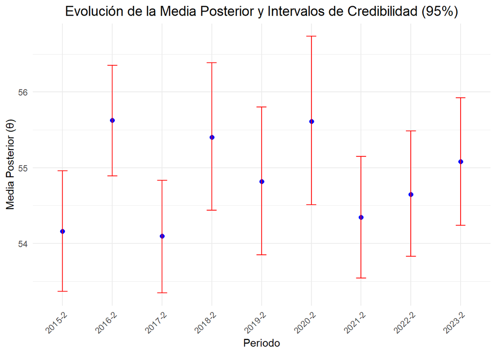

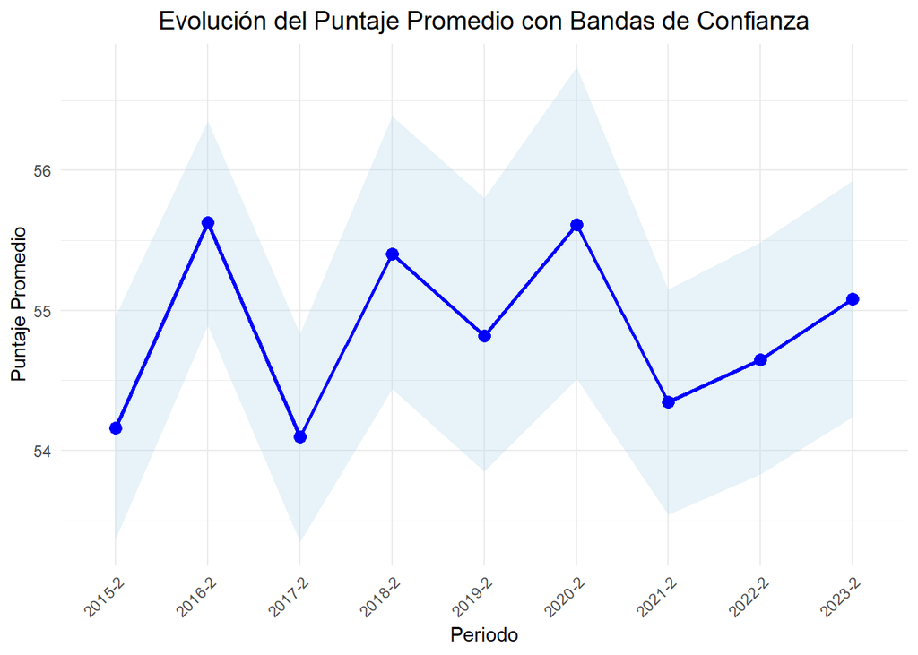

5. Para Bogotá en todos los periodos ($t=1,\ldots,9$), calcule la media posterior y el intervalo de credibilidad al 95% de confianza para el coeficiente de variación $\zeta$. Presente los resultados mediante una visualización que muestre simultáneamente las medias posteriores y los intervalos de credibilidad.

Inferencia sobre el coeficiente de variación del puntaje promedio de Bogotá a través del tiempo

|  | Estimación | CV | L. Inf | L. Sup |
| --- | --- | --- | --- | --- |
| 2015-2 | 22.362 | 0.025 | 21.304 | 23.497 |
| 2016-2 | 19.633 | 0.024 | 18.725 | 20.606 |
| 2017-2 | 20.678 | 0.024 | 19.733 | 21.690 |
| 2018-2 | 20.174 | 0.033 | 18.949 | 21.531 |
| 2019-2 | 20.549 | 0.033 | 19.288 | 21.940 |
| 2020-2 | 17.929 | 0.042 | 16.547 | 19.467 |
| 2021-2 | 20.834 | 0.026 | 19.773 | 21.938 |
| 2022-2 | 20.987 | 0.027 | 19.917 | 22.123 |
| 2023-2 | 21.776 | 0.026 | 20.673 | 22.963 |

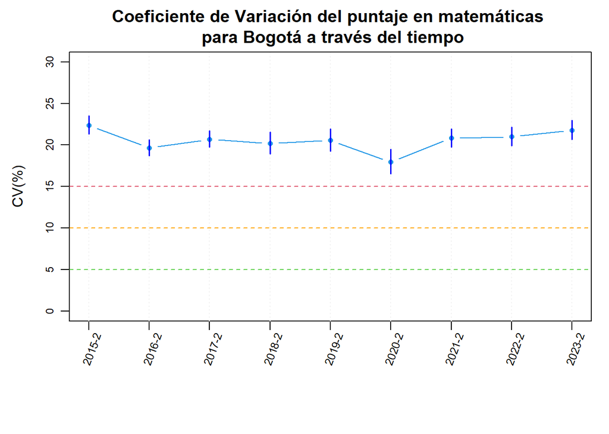

6. Considere el parámetro $\eta_{t,k} = \theta_t-\theta_{t-k}$, para algún $k=1,\ldots,t-1$. Para Bogotá, calcule la media posterior y el intervalo de credibilidad al 95% de confianza para $\eta_{9,k}$, para cada $k=1,\ldots,8$. Presente los resultados mediante una visualización que muestre simultáneamente las medias posteriores y los intervalos de credibilidad.

|  | Estimación | LI | LS |
| --- | --- | --- | --- |
| $\eta_{9,1}$ | 0.4319831 | -0.7431620 | 1.5834279 |
| $\eta_{9,2}$ | 0.7364352 | -0.4046575 | 1.8897647 |
| $\eta_{9,3}$ | -0.5325337 | -1.9151071 | 0.8658900 |
| $\eta_{9,4}$ | 0.2623209 | -1.0550157 | 1.5767503 |
| $\eta_{9,5}$ | -0.3232704 | -1.6247022 | 0.9722876 |
| $\eta_{9,6}$ | 0.9852949 | -0.1400950 | 2.1056060 |
| $\eta_{9,7}$ | -0.5437484 | -1.6539746 | 0.5732520 |
| $\eta_{9,8}$ | 0.9195200 | -0.2209856 | 2.0936569 |

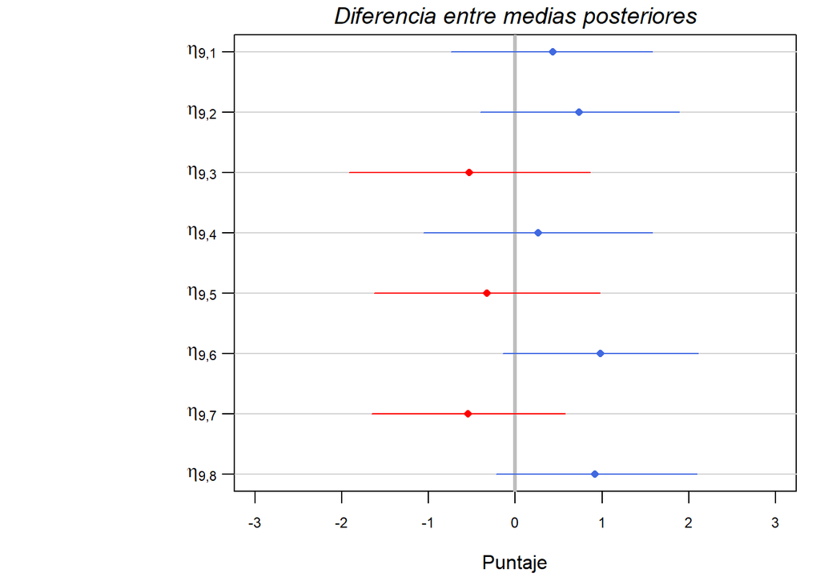

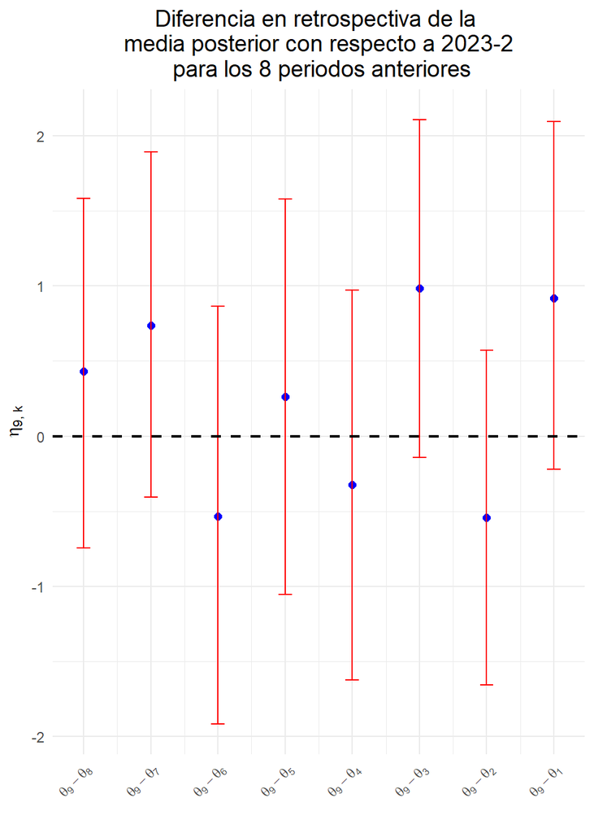

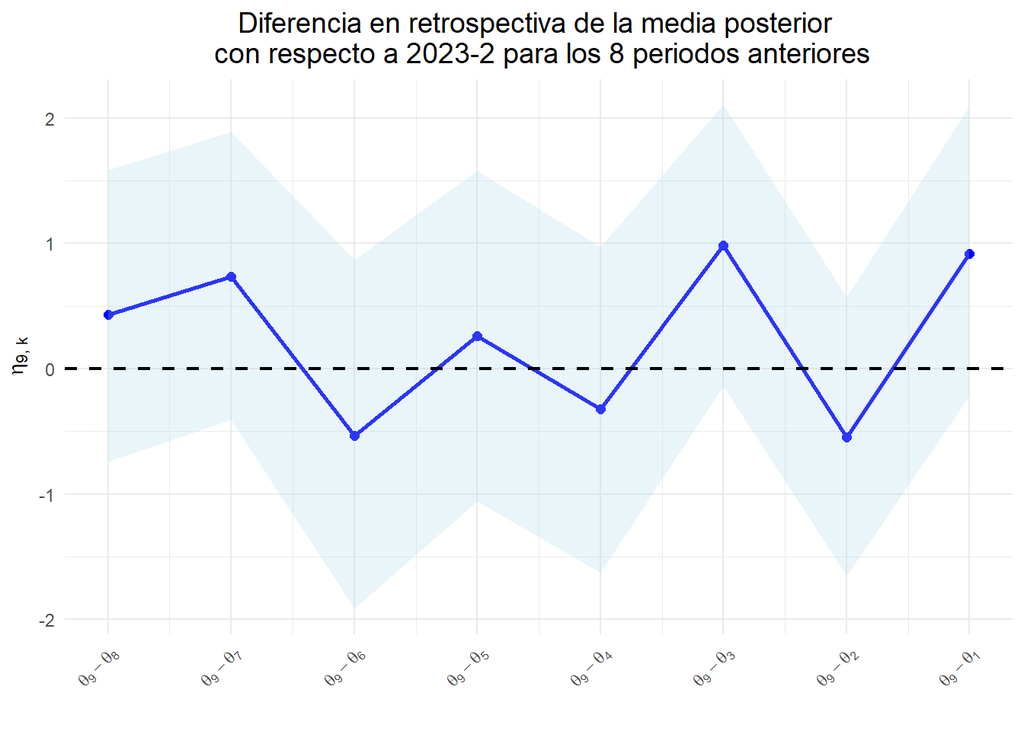

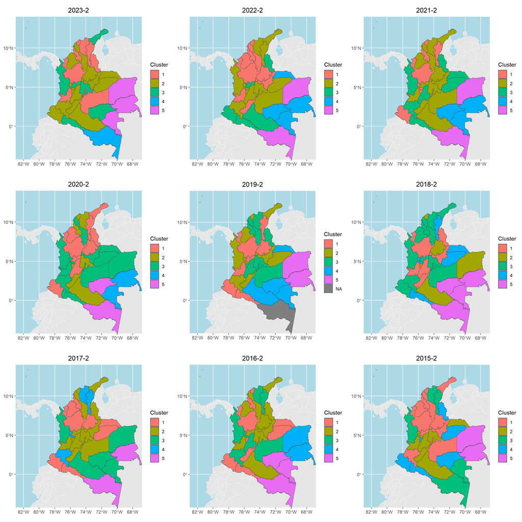